# Exercise session 2: multivariate extremes

Anna Kiriliouk and Johan Segers

UCLouvain, October 2024

```r
library(mev)
library(ismev)
library(copula)
library(ExtremalDep)
library(evd) # function fbved
library(graphicalExtremes)
library(extremis)
library(SpatialExtremes)
```

```r
#load("Wind.RData")
load("Temp.RData")
#load("Ex1uni.RData")
Temp <- as.data.frame(Temp)
```

Packages to be installed: `copula`, `evd`, `ismev`, `maps`. You can install a package by `install.packages("copula")` etc.

The data consist of annual maxima of daily maximum temperatures for the years 1950–2018 for $d = 54$ stations around Belgium. Derived from the homogenized E-OBS dataset E-OBS v19.0eHOM data, made available in the supplementary material of Auld et al. (2023).

The aim is to estimate **joint probabilities** of high annual temperatures - at multiple locations *simultaneously* (AND), - *at least* one location (OR).

We will compare various estimates: 1. the empirical probability 2. by applying univariate extreme-value theory (EVT) to the maximum of maxima 3. by fitting a max-stable distribution to the vector of component-wise maxima - non-parametric estimate of the Pickands dependence function - parametric estimate, via a two-stage procedure - margins estimated via fitting univariate generalized extreme-value (GEV) distributions - margins estimated via the empirical cumulative distribution function (cdf)

# 1 Warm-up: the data

We load the data and ensure that the temperature data object is of class `data.frame`.

```r
load("Temp.RData")
Temp <- as.data.frame(Temp)
```

This loads three objects: an $(n \times d)$ matrix of observations, a $(d \times 2)$ matrix of coordinates and a vector of years.

Let’s plot the locations:

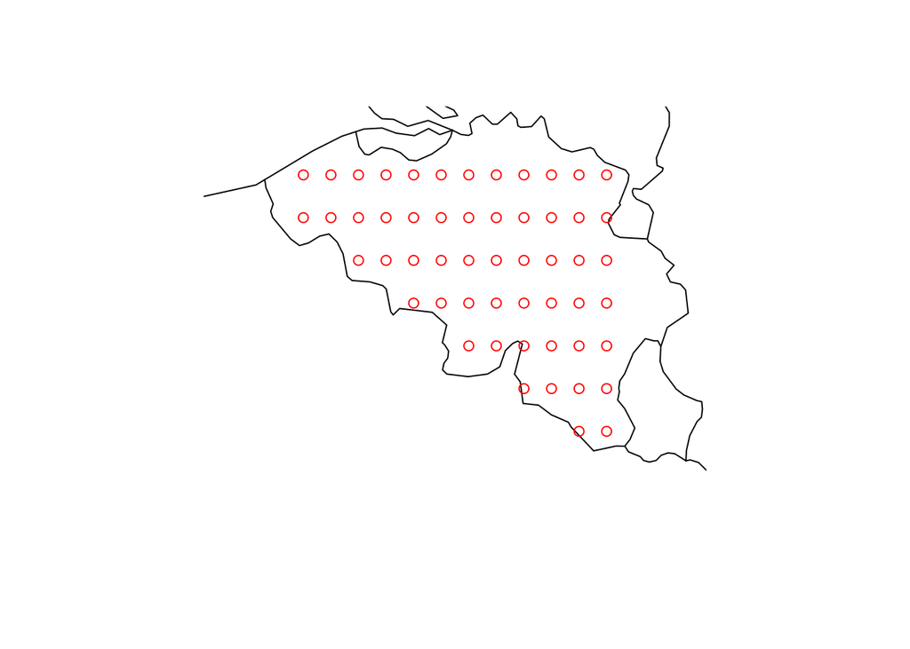

```r
library(maps)
map("world", xlim = c(2,6.5), ylim = c(49,51.5))
points(cbind(TempCoord[,"longitude"], TempCoord[,"latitude"]), col = "red")
```

For simplicity, we’ll select three locations, in the neighbourhood of Middelkerke, Louvain-la-Neuve, and Virton:

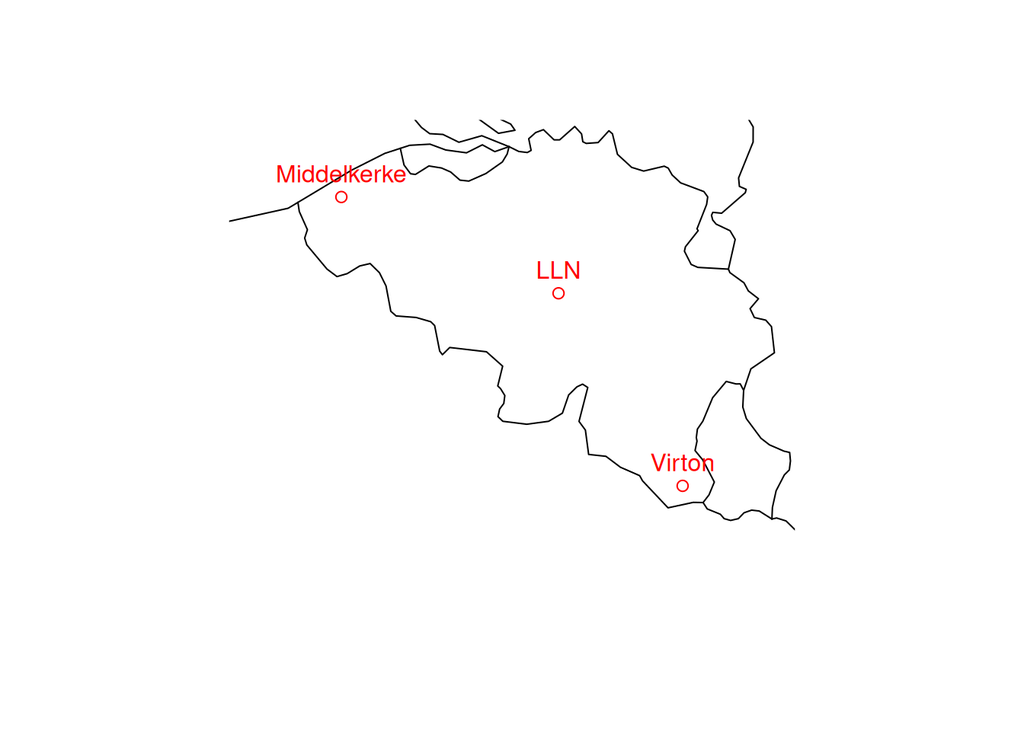

```r
cities <- as.data.frame(rbind(
  c("Middelkerke", 1),
  c("LLN", 30),
  c("Virton", 54)
))
names(cities) <- c("name", "ID")
cities$ID <- as.integer(cities$ID)
M <- Temp[,cities$ID]
names(M) <- cities$name
map("world", xlim = c(2,6.5), ylim = c(49,51.5))
points(TempCoord[cities$ID,], col = "red")
text(TempCoord[cities$ID,], col = "red", labels = cities$name, pos = 3)
```

**Make a scatterplot of the data. Use the function `plot()`, after coercing the data matrix to be of class `data.frame` with the function `as.data.frame()`.**

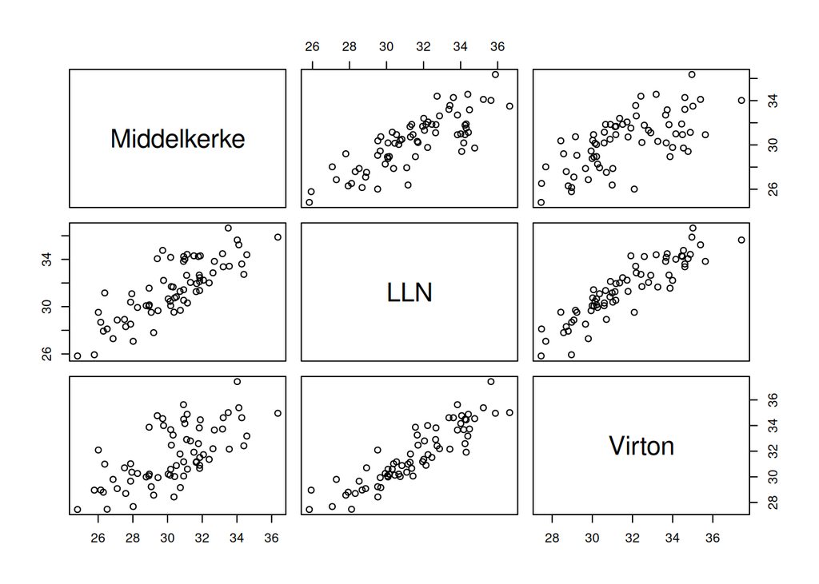

```r
plot(M)
```

**Compute some summary statistics of the data, such as the range of the annual maxima.**

```r
summary(M)
```

```
##   Middelkerke         LLN            Virton
##  Min.   :24.81   Min.   :25.83   Min.   :27.45
##  1st Qu.:28.92   1st Qu.:29.93   1st Qu.:30.06
##  Median :30.51   Median :31.43   Median :31.18
##  Mean   :30.34   Mean   :31.49   Mean   :31.67
##  3rd Qu.:31.85   3rd Qu.:33.61   3rd Qu.:33.68
##  Max.   :36.36   Max.   :36.65   Max.   :37.43
```

# 2 Empirical probability

We are interested in probabilities of the type
$$\begin{align*}
&\operatorname{\mathsf{P}}(M_i > u_i \text{ and } M_j > u_j)
&
&\operatorname{\mathsf{P}}(M_1 > u_1 \text{ and } M_2 > u_2
\text{ and } M_3 > u_3) \\
&\operatorname{\mathsf{P}}(M_i > u_i \text{ or } M_j > u_j)
&
&\operatorname{\mathsf{P}}(M_1 > u_1 \text{ or } M_2 > u_2
\text{ or } M_3 > u_3)
\end{align*}$$

**Estimate the above probabilities for $u_1 = u_2 = u_3 = 35^\circ$ by the empirical probabilities, that is, the frequency of the events in the sample.** In R, the logical operators are `&` (AND) and `|` (OR).

```r
# Here and below, it's certainly possible to write more elegant and general code, using loops etc.
u <- 35

mean((M[,1] > u) & (M[,2] > u))
```

```
## [1] 0.01449275
```

```r
mean((M[,1] > u) & (M[,3] > u))
```

```
## [1] 0
```

```r
mean((M[,2] > u) & (M[,3] > u))
```

```
## [1] 0.04347826
```

```r
mean((M[,1] > u) | (M[,2] > u))
```

```
## [1] 0.05797101
```

```r
mean((M[,1] > u) | (M[,3] > u))
```

```
## [1] 0.07246377
```

```r
mean((M[,2] > u) | (M[,3] > u))
```

```
## [1] 0.07246377
```

```r
mean((M[,1] > u) & (M[,2] > u) & (M[,3] > u))
```

```
## [1] 0
```

```r
mean((M[,1] > u) | (M[,2] > u) | (M[,3] > u))
```

```
## [1] 0.07246377
```

# 3 Univariate EVT applied to the maximum of the maxima

**For each year, extract the maximum of the maxima at two or three locations.** Use the function `pmax()`. For our three cities, this gives four series of maxima (three pairs and one triple).

```r
M12 <- pmax(M[,1], M[,2])
M13 <- pmax(M[,1], M[,3])
M23 <- pmax(M[,2], M[,3])

M123 <- pmax(M[,1], M[,2], M[,3])
```

**Fit a univariate GEV distribution to each of the series, by the function `gev.fit()` in `ismev`.**

```r
library(ismev)
gev12 <- gev.fit(M12)$mle
```

```
## $conv
## [1] 0
##
## $nllh
## [1] 157.7958
##
## $mle
## [1] 30.8769670  2.5003131 -0.3668494
##
## $se
## [1] 0.33029643 0.23994536 0.07777694
```

```r
gev13 <- gev.fit(M13)$mle
```

```
## $conv
## [1] 0
##
## $nllh
## [1] 153.0241
##
## $mle
## [1] 31.0970347  2.1730271 -0.2483739
##
## $se
## [1] 0.29270066 0.21223078 0.08794386
```

```r
gev23 <- gev.fit(M23)$mle
```

```
## $conv
## [1] 0
##
## $nllh
## [1] 155.0525
##
## $mle
## [1] 31.161202  2.251698 -0.262173
##
## $se
## [1] 0.30523099 0.22392218 0.09307167
```

```r
gev123 <- gev.fit(M123)$mle
```

```
## $conv
## [1] 0
##
## $nllh
## [1] 154.5012
##
## $mle
## [1] 31.2771796  2.2411324 -0.2673389
##
## $se
## [1] 0.30347061 0.22245418 0.09255657
```

**For the OR version, calculate the probabilities by the GEV fit.** To do so, use
$$\operatorname{\mathsf{P}}(M_i > u \text{ or } M_j > u) =
\operatorname{\mathsf{P}}[\max(M_i, M_j) > u].$$
The GEV cumulative distribution function is implemented in `pgev()` of the package `evd`.

```r
library(evd)
p.or.12 <- pgev(q = u, loc = gev12[1], scale = gev12[2], shape = gev12[3], lower.tail = FALSE)
p.or.13 <- pgev(q = u, loc = gev13[1], scale = gev13[2], shape = gev13[3], lower.tail = FALSE)
p.or.23 <- pgev(q = u, loc = gev23[1], scale = gev23[2], shape = gev23[3], lower.tail = FALSE)
p.or.123 <- pgev(q = u, loc = gev123[1], scale = gev123[2], shape = gev123[3], lower.tail = FALSE)
```

```r
gev1 <- gev.fit(M[,1])$mle
```

```
## $conv
## [1] 0
##
## $nllh
## [1] 158.9045
##
## $mle
## [1] 29.4922582  2.4543168 -0.2947117
##
## $se
## [1] 0.32177434 0.22536062 0.06544285
```

```r
gev2 <- gev.fit(M[,2])$mle
```

```
## $conv
## [1] 0
##
## $nllh
## [1] 158.416
##
## $mle
## [1] 30.7234497  2.5197043 -0.3653727
##
## $se
## [1] 0.3324749 0.2418652 0.0766866
```

```r
gev3 <- gev.fit(M[,3])$mle
```

```
## $conv
## [1] 0
##
## $nllh
## [1] 153.0059
##
## $mle
## [1] 30.8001243  2.1248687 -0.2120946
##
## $se
## [1] 0.2891958 0.2108645 0.0945878
```

```r
(p1 <- pgev(q = u, loc = gev1[1], scale = gev1[2], shape = gev1[3], lower.tail = FALSE))
```

```
## [1] 0.0250507
```

```r
(p2 <- pgev(q = u, loc = gev2[1], scale = gev2[2], shape = gev2[3], lower.tail = FALSE))
```

```
## [1] 0.06827108
```

```r
(p3 <- pgev(q = u, loc = gev3[1], scale = gev3[2], shape = gev3[3], lower.tail = FALSE))
```

```
## [1] 0.07425482
```

```r
(p.and.12 <- p1 + p2 - p.or.12)
```

```
## [1] 0.01686942
```

```r
(p.and.13 <- p1 + p3 - p.or.13)
```

```
## [1] 0.01078875
```

```r
(p.and.23 <- p2 + p3 - p.or.23)
```

```
## [1] 0.04337165
```

# 4 Nonparametric estimation of a max-stable distribution

We will estimate the Pickands dependence function non-parametrically and then combine the estimated dependence structure with the parametric GEV margins to estimate the multivariate excess probabilities. For simplicity, we will limit ourselves to the bivariate case.

### 4.0.1 Estimation and visualization of the Pickands dependence function

**For each of the three pairs of cities, make a graph of the Capéraà-Fougères-Genest estimator $\hat{\Pidf}$ of the Pickands dependence function $\Pidf$.**

Use the function `An.biv()` of the package `copula` to compute the estimate and use `curve` to make the plot.

**For each pair, also compute an estimate of the dependence coefficient $\chi$.** To do so, put
$$\hat{\chi} = 2 \left\{1 - \hat{\Pidf}(0.5)\right\}.$$
Do you notice a link between the value of $\hat{\chi}$ and the distance between the cities? Optionally: visualize $\hat{\chi}$ on the plot of $\hat{\Pidf}$.

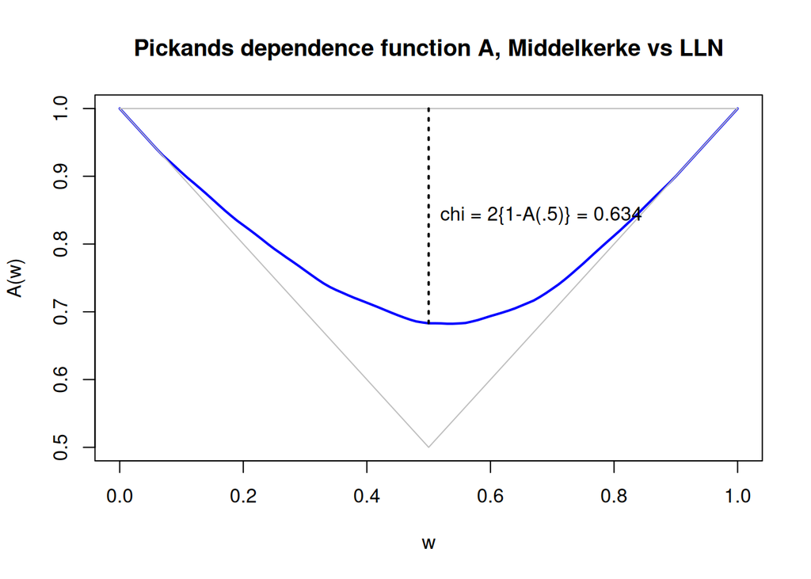

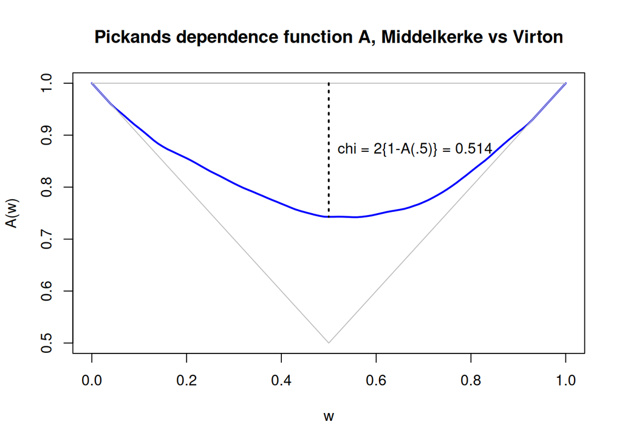

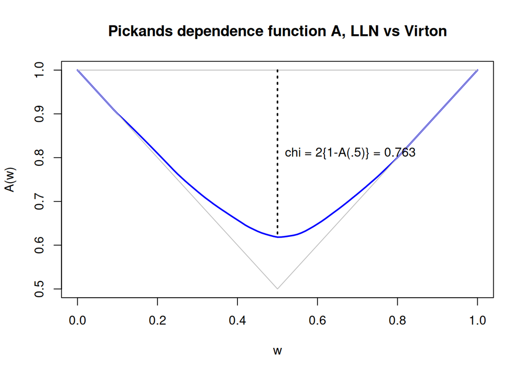

```r
library(copula)
for (i in (1:2)) {
  for (j in (i+1):3) {
    curve(An.biv(M[,c(i,j)], x, estimator = "CFG"),
          xlab = "w", ylab = "A(w)",
          main = paste("Pickands dependence function A,",
                       cities$name[i], "vs", cities$name[j]),
          ylim = c(0.5,1),
          col = "blue", lwd = 2)
    lines(c(0, 0.5, 1), c(1,0.5,1), col = "gray")
    lines(c(0,1),c(1,1), col = "gray")
    Ahalf <- An.biv(M[,c(i,j)], w=0.5)
    lines(c(0.5,0.5), c(1, Ahalf), lty = "dotted", lwd = 2)
    text(x = 0.5, y = (Ahalf+1)/2,
         labels = paste("chi = 2{1-A(.5)} =", round(2*(1-Ahalf),3)),
         pos = 4
         )
  }
}
```

Interpret the value of $\hat{\chi}$ in terms of the locations of the cities.

## 4.1 Estimation of the joint excess probability

For a bivariate max-stable distribution function $G$ with margins $G_1$ and $G_2$ and Pickands dependence function $\Pidf$, we have
$$G(x_1,x_2) = (u_1u_2)^{\Pidf(w)},
\qquad
\left\{
\begin{array}{@{}r{\;=\;}l}
u_1 & G_1(x_1) \\
u_2 & G_2(x_2) \\
w & \log(u_2) / \log(u_1 u_2)
\end{array}
\right.$$
**For a pair of cities of your choice, combine the estimates of the marginal (non-)excess probabilities and the estimate of the Pickands dependence function to obtain the required excess probabilities.** Note that, for the pair $(i, j)$, say, we have
$$\begin{align*}
\operatorname{\mathsf{P}}(M_i > x \text{ or } M_j > x)
&= 1 - G_{ij}(x,x) \\
\operatorname{\mathsf{P}}(M_i > x \text{ and } M_j > x)
&= \operatorname{\mathsf{P}}(M_i > x) +
\operatorname{\mathsf{P}}(M_j > x) - \operatorname{\mathsf{P}}(M_i
> x \text{ or } M_j > x).
\end{align*}$$

```r
(G1 <- pgev(q = u, loc = gev1[1], scale = gev1[2], shape = gev1[3], lower.tail = TRUE))
```

```
## [1] 0.9749493
```

```r
(G2 <- pgev(q = u, loc = gev2[1], scale = gev2[2], shape = gev2[3], lower.tail = TRUE))
```

```
## [1] 0.9317289
```

```r
(G3 <- pgev(q = u, loc = gev3[1], scale = gev3[2], shape = gev3[3], lower.tail = TRUE))
```

```
## [1] 0.9257452
```

```r
(A12 <- An.biv(x = M[,c(1,2)], w = log(G2)/log(G1*G2), estimator = "CFG"))
```

```
## [1] 0.7598188
```

```r
(p.or.12.Pick <- 1-(G1*G2)^A12)
```

```
## [1] 0.07040457
```

```r
(p.and.12.Pick <- p1+p2-p.or.12.Pick)
```

```
## [1] 0.02291721
```

```r
(A13 <- An.biv(x = M[,c(1,3)], w = log(G3)/log(G1*G3), estimator = "CFG"))
```

```
## [1] 0.7975742
```

```r
(p.or.13.Pick <- 1-(G1*G3)^A13)
```

```
## [1] 0.07851811
```

```r
(p.and.13.Pick <- p1+p3-p.or.13.Pick)
```

```
## [1] 0.02078741
```

```r
(A23 <- An.biv(x = M[,c(2,3)], w = log(G3)/log(G2*G3), estimator = "CFG"))
```

```
## [1] 0.6199258
```

```r
(p.or.23.Pick <- 1-(G2*G3)^A23)
```

```
## [1] 0.08759216
```

```r
(p.and.23.Pick <- p2+p3-p.or.23.Pick)
```

```
## [1] 0.05493374
```

Compare the probabilities with the one of the previous approaches.

# 5 Parametric modelling of a max-stable distribution

Now let’s assume the bivariate GEV distribution to a parametric family. We will first estimate the parameters by maximum likelihood and then compute the multivariate excess probabilities of interest in the fitted parametric model.

For the *marginal* GEV parameters, we have two choices: - estimate the parameters jointly with the dependence parameter; - use a two-stage procedure: in a first stage, we fit the marginal GEV parameters separately to each margin; in a second stage, we fix the marginal parameters and estimate the dependence parameter.

(A third option would be to use the pseudo-likelihood procedure, estimating the margins nonparametrically with the empirical cdf.)

For the parametric estimate, we will use the function `fbvevd()` from the package `evd`. To evaluate probabilities under the fitted model, use the function `pmvevd()` from the same package; alternatively, use the function `pCopula()` from the `copula` package, knowing that the logistic model in EVT is actually the same as the Gumbel copula. Recall that the link between a bivariate cdf $G$ and its margins $G_1, G_2$ is given by
$$G(x_1,x_2) = C \left(G_1(x_1), G_2(x_2)\right)$$
where $C$ is the copula of $G$.

## 5.1 Joint parameter estimation

**Fit the bivariate GEV with the logistic dependence model, estimating all parameters jointly.**

```r
library(evd)
res12 <- fbvevd(x = M[,c(1,2)],
                model = "log")$estimate
```

**Estimate the probabilities $\operatorname{\mathsf{P}}(M_i > u)$, $\operatorname{\mathsf{P}}(M_j > u)$, $\operatorname{\mathsf{P}}(M_i > u \text{ or } M_j > u)$ and $\operatorname{\mathsf{P}}(M_i > u \text{ and } M_j > u)$.** Use the functions `pgev()` for the marginal ones and `pmvevd()` for the joint one $\operatorname{\mathsf{P}}(M_i \le u \text{ and } M_j \le u)$, the bivariate distribution function.

```r
(G1 <- pgev(q = u, loc = res12[1], scale = res12[2], shape = res12[3]))
```

```
##    shape1
## 0.9501467
```

```r
(G2 <- pgev(q = u, loc = res12[4], scale = res12[5], shape = res12[6]))
```

```
##    shape2
## 0.9082471
```

```r
(G12 <- pmvevd(q = c(u, u),
               dep = res12[7],
               d = 2,
               mar = list(res12[1:3], res12[4:6]),
               model = "log"))
```

```
##       dep
## 0.9011762
```

```r
(p.or.12.log <- 1-G12)
```

```
##        dep
## 0.09882378
```

```r
(p1 <- 1-G1)
```

```
##     shape1
## 0.04985327
```

```r
(p2 <- 1-G2)
```

```
##     shape2
## 0.09175293
```

```r
(p.and.12.log <- p1+p2-p.or.12.log)
```

```
##     shape1
## 0.04278242
```

## 5.2 Two-stage estimation procedure

Now do the same, but using the two-stage procedure.

```r
(gev.par1 <- gev.fit(M[,1])$mle)
```

```
## $conv
## [1] 0
##
## $nllh
## [1] 158.9045
##
## $mle
## [1] 29.4922582  2.4543168 -0.2947117
##
## $se
## [1] 0.32177434 0.22536062 0.06544285
```

```
## [1] 29.4922582  2.4543168 -0.2947117
```

```r
(gev.par2 <- gev.fit(M[,2])$mle)
```

```
## $conv
## [1] 0
##
## $nllh
## [1] 158.416
##
## $mle
## [1] 30.7234497  2.5197043 -0.3653727
##
## $se
## [1] 0.3324749 0.2418652 0.0766866
```

```
## [1] 30.7234497  2.5197043 -0.3653727
```

**Estimate the dependence parameter by `fbvevd()`, fixing the marginal parameters.**

```r
res12 <- fbvevd(x = M[,c(1,2)],
                loc1 = gev.par1[1],
                scale1 = gev.par1[2],
                shape1 = gev.par1[3],
                loc2 = gev.par2[1],
                scale2 = gev.par2[2],
                shape2 = gev.par2[3],
                model = "log")$estimate
```

**Estimate the probabilities $\operatorname{\mathsf{P}}(M_i > u)$, $\operatorname{\mathsf{P}}(M_j > u)$, $\operatorname{\mathsf{P}}(M_i > u \text{ or } M_j > u)$ and $\operatorname{\mathsf{P}}(M_i > u \text{ and } M_j > u)$.**

```r
(G1 <- pgev(q = u, loc = gev.par1[1], scale = gev.par1[2], shape = gev.par1[3]))
```

```
## [1] 0.9749493
```

```r
(G2 <- pgev(q = u, loc = gev.par2[1], scale = gev.par2[2], shape = gev.par2[3]))
```

```
## [1] 0.9317289
```

```r
(G12 <- pmvevd(q = c(u, u),
               dep = res12,
               d = 2,
               mar = list(gev.par1, gev.par2),
               model = "log"))
```

```
##      dep
## 0.928288
```

```r
(p.or.12.log <- 1-G12)
```

```
##        dep
## 0.07171204
```

```r
(p1 <- 1-G1)
```

```
## [1] 0.0250507
```

```r
(p2 <- 1-G2)
```

```
## [1] 0.06827108
```

```r
(p.and.12.log <- p1+p2-p.or.12.log)
```

```
##        dep
## 0.02160974
```

Optionally: **Fit the bivariate GEV with the Hüsler—Reiss dependence model.** To calculate the bivariate GEV, use the function `pcopula()` from the `copula` package. Among the two models, which one would you prefer? (Hint: inspect the value of the AIC.)